# Simulating Covariance Data to Plan a Study

Bill Peterman

## 1 Why simulate before you sample?

Landscape-genetic studies are expensive: every additional sampling site means field time and cost. Before committing to a design it is worth asking, in advance:

- **How many sampling sites** do I need to detect the conditional conductance association specified in my scenario?
- **How much approximately independent marker information** (represented by the supplied `nu`) do I need?
- **Where should the sites go**: spread evenly across the landscape, or placed some other way?
- If I run the analysis, **how often will I recover the generating parameters under this model**, and how often will sampling variation obscure them?

`terradish` answers these questions by simulation. Because the Wishart covariance model has a tractable generative form, you can draw synthetic covariance matrices from a *known* conductance surface, refit the model, and measure how reliably the generating parameters are recovered, all without any forward-time genetic simulation. This vignette shows how.

This is a **design tool**, not a replacement for individual-based or coalescent simulation. It assumes the fitted model is correctly specified and asks: given that model and this set of scenarios, how much data do I need? The answer is conditional on the graph, parameters, candidate set, likelihood, optimizer, and sampling strategies evaluated here.

## 2 The generative model

A covariance-based `terradish` fit (see `vignette("wishart-covariance", package = "terradish")`) assumes the observed genetic covariance matrix `S` is a noisy realization of a structured covariance:

$$\Sigma = \tau \, E(\theta) + \sigma\, I,
\qquad
\nu\, S \sim \mathrm{Wishart}(\nu, \Sigma)$$

where:

- $E(\theta)$ is the **conductance-implied covariance**: the generalized inverse of the graph Laplacian at conductance parameters $\theta$. This is the part that carries the landscape signal.
- $\tau \ge 0$ scales that signal.
- $\sigma \ge 0$ is a diagonal residual-variance term for covariance variation not represented by $E(\theta)$. It is not a direct estimate of drift, population size, or a Gaussian smoothing scale.
- $\nu$ is the supplied **effective Wishart degrees of freedom**, not a fitted parameter. It can be interpreted as the effective number of approximately independent marker contributions. Large $\nu$ gives draws tightly clustered around $\Sigma$; small $\nu$ gives noisier draws.

`simulate_covariance_response()` draws from exactly this model, and `covariance_response_power()` automates the simulate-refit-summarize loop across many designs. Fitted `wishart_covariance()` models store the nugget internally on the log scale, but both simulation helpers accept $\sigma$ as the nonnegative variance added to the diagonal.

For a fixed landscape template, $\tau / \sigma$ is a convenient **signal-to-nugget ratio**. Larger values place more weight on the landscape-implied covariance relative to diagonal noise. The ratio should be interpreted within a fixed template because rescaling $E(\theta)$ also changes its meaning.

> **Keep `nu` front of mind.** As explained in `vignette("wishart-covariance", package = "terradish")`, `nu` acts as an *effective sample size*. It does not change the *point estimates* recovered from a given covariance matrix, but it controls their precision (standard errors scale as $1/\sqrt{\nu}$) and therefore the **statistical power** to detect a nonzero coefficient under the simulated model. Sample size and marker design are important study-design levers, but the effective `nu` may be smaller than the raw marker count because of dependence. For microsatellites, use the locus count as the primary value and $\sum_l(K_l-1)$ only as a larger sensitivity value.

## 3 Set up a landscape template

We need a landscape to define the conductance surface. Any `conductance_surface()` works; here we reuse the bundled *Melipona* rasters as a realistic template. Build the surface with `saveStack = TRUE` so the simulation tools can subset focal sites efficiently.

```r
library(terradish)
library(terra)

data(melip)
melip.altitude    <- terra::unwrap(melip.altitude)
melip.forestcover <- terra::unwrap(melip.forestcover)
melip.coords      <- terra::unwrap(melip.coords)

covariates <- c(melip.altitude, melip.forestcover)
names(covariates) <- c("altitude", "forestcover")
covariates <- scale_covariates(covariates)

surface <- conductance_surface(covariates, melip.coords,
                               directions = 8, saveStack = TRUE)

cat("Candidate focal sites:", length(surface$demes), "\n")
```

```
#> Candidate focal sites: 37
```

We also fix the **generating parameters** we want to recover: a moderate positive forest-cover coefficient and a moderate negative altitude coefficient for log conductance. These are illustrative simulation settings, not estimates from the bundled *Melipona* genetic response. The bundled rasters provide a realistic landscape template, while the synthetic covariance response is generated from the values below.

```r
theta_true <- c(forestcover = 0.6, altitude = -0.4)
tau_true   <- 2   # strength of the landscape signal
sigma_true <- 1   # nugget (non-landscape variance)
```

## 4 A single simulated data set

`simulate_covariance_response()` returns one covariance matrix (plus the ingredients used to build it). This is precisely the object you would otherwise compute from real genotypes with `cov_from_genetic_data()`.

```r
sim <- simulate_covariance_response(
  theta             = theta_true,
  formula           = ~ forestcover + altitude,
  data              = surface,
  conductance_model = loglinear_conductance,
  tau               = tau_true,
  sigma             = sigma_true,
  nu                = 100,     # 100 effective independent marker contributions
  seed              = 1
)

dim(sim$covariance)        # one row/column per focal site
```

```
#> [1] 37 37
```

```r
round(sim$covariance[1:4, 1:4], 3)
```

```
#>        [,1]   [,2]   [,3]   [,4]
#> [1,]  1.113  0.323 -0.288  0.044
#> [2,]  0.323  1.562 -0.304 -0.053
#> [3,] -0.288 -0.304  1.947  0.267
#> [4,]  0.044 -0.053  0.267  1.245
```

Refitting estimates the parameters used to generate the data. One draw may depart substantially from the generating values:

```r
fit <- terradish(
  sim$covariance ~ forestcover + altitude,
  data              = surface,
  conductance_model = loglinear_conductance,
  measurement_model = wishart_covariance,
  nu                = 100
)

rbind(true      = theta_true,
      estimated = round(coef(fit), 3))
```

```
#>           forestcover altitude
#> true            0.600   -0.400
#> estimated       0.604   -0.447
```

A single replicate only tells you what happened *once*. To characterize a design you must repeat the draw many times.

## 5 The role of effective `nu` in statistical power

Holding the sampling design fixed, larger effective `nu` means more precise estimates and higher model-based power. The amount of conductance-implied covariance signal also matters. To make both patterns easy to see, we temporarily isolate a modest altitude coefficient and vary the signal-to-nugget ratio while holding the landscape template fixed.

```r
altitude_surface <- conductance_surface(
  covariates[["altitude"]], melip.coords,
  directions = 8, saveStack = TRUE
)

screen_theta  <- c(altitude = -0.25)
screen_sigma  <- 1
signal_ratios <- c(0.5, 1, 2, 4)

screen_power <- function(sample_size, nu, signal_ratio,
                         nsim = 10, seed = 100) {
  assessment <- covariance_response_power(
    theta        = screen_theta,
    formula      = ~ altitude,
    data         = altitude_surface,
    sample_sizes = sample_size,
    strategies   = "spacefill",
    tau          = signal_ratio * screen_sigma,
    sigma        = screen_sigma,
    nu           = nu,
    nsim         = nsim,
    seed         = seed,
    control      = NewtonRaphsonControl(maxit = 10, verbose = FALSE)
  )
  out <- assessment$parameter_summary
  data.frame(sample_size, nu, signal_ratio,
             fit_rate = out$fit_rate, power = out$power)
}

screen_grid <- function(sample_sizes, nu_values, seed) {
  grid <- expand.grid(sample_size = sample_sizes, nu = nu_values,
                      signal_ratio = signal_ratios)
  do.call(rbind, Map(screen_power,
                     sample_size = grid$sample_size,
                     nu = grid$nu,
                     signal_ratio = grid$signal_ratio,
                     seed = seed + seq_len(nrow(grid))))
}

marker_power <- screen_grid(sample_sizes = 20,
                            nu_values = c(20, 50, 100, 200),
                            seed = 100)
marker_power
```

```
#>    sample_size  nu signal_ratio fit_rate power
#> 1           20  20          0.5      0.9   0.2
#> 2           20  50          0.5      0.9   0.2
#> 3           20 100          0.5      0.9   0.1
#> 4           20 200          0.5      1.0   0.3
#> 5           20  20          1.0      1.0   0.2
#> 6           20  50          1.0      1.0   0.2
#> 7           20 100          1.0      1.0   0.2
#> 8           20 200          1.0      1.0   0.6
#> 9           20  20          2.0      1.0   0.1
#> 10          20  50          2.0      1.0   0.5
#> 11          20 100          2.0      1.0   0.8
#> 12          20 200          2.0      1.0   0.9
#> 13          20  20          4.0      0.9   0.1
#> 14          20  50          4.0      1.0   0.5
#> 15          20 100          4.0      1.0   0.7
#> 16          20 200          4.0      1.0   1.0
```

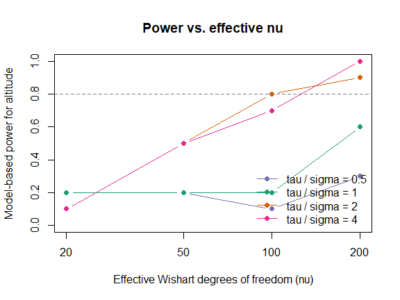

*Power responds to effective Wishart degrees of freedom and the tau / sigma signal ratio.* Each point is the proportion of 10 simulated data sets in which the altitude coefficient had the correct sign and a two-sided Wald p-value below alpha = 0.05. The 20 sampling sites are held fixed. The small demonstration grid leaves visible Monte Carlo variation.

```r
cols <- setNames(c("#7570b3", "#1b9e77", "#d95f02", "#e7298a"),
                 signal_ratios)
plot(NA, xlim = range(marker_power$nu), ylim = c(0, 1), log = "x",
     xlab = "Effective Wishart degrees of freedom (nu)",
     ylab = "Model-based power for altitude",
     main = "Power vs. effective nu")
for (signal_ratio in signal_ratios) {
  sub <- marker_power[marker_power$signal_ratio == signal_ratio, ]
  lines(sub$nu, sub$power, type = "b", pch = 19,
        col = cols[as.character(signal_ratio)])
}
abline(h = 0.8, lty = 2, col = "grey50")
legend("bottomright", legend = paste("tau / sigma =", signal_ratios),
       col = cols, lty = 1, pch = 19, bty = "n")
```

The curves show the conditional tradeoff in this simulation. Additional independent marker information helps, but it cannot fully rescue a weak conductance-implied covariance signal. Conversely, stronger simulated signal reduces the effective `nu` needed to reach a specified power target.

For covariance simulation, use `nu` values at least as large as the number of sampled sites. `simulate_covariance_response()` uses `stats::rWishart()`, which requires the Wishart degrees of freedom to be at least the covariance-matrix dimension.

## 6 The role of sample size in statistical power

Now hold the effective Wishart degrees of freedom fixed at `nu = 100` and vary the number of sampling sites. Each curve again represents a different $\tau / \sigma$ ratio.

```r
sample_grid <- c(8, 12, 20, 34)
site_power <- screen_grid(sample_sizes = sample_grid,
                          nu_values = 100,
                          seed = 200)
site_power
```

```
#>    sample_size  nu signal_ratio fit_rate power
#> 1            8 100          0.5      0.8   0.1
#> 2           12 100          0.5      0.9   0.1
#> 3           20 100          0.5      1.0   0.2
#> 4           34 100          0.5      1.0   0.1
#> 5            8 100          1.0      0.9   0.5
#> 6           12 100          1.0      1.0   0.4
#> 7           20 100          1.0      1.0   0.4
#> 8           34 100          1.0      1.0   0.4
#> 9            8 100          2.0      0.9   0.3
#> 10          12 100          2.0      1.0   0.7
#> 11          20 100          2.0      1.0   0.5
#> 12          34 100          2.0      1.0   0.9
#> 13           8 100          4.0      1.0   0.6
#> 14          12 100          4.0      1.0   0.9
#> 15          20 100          4.0      1.0   0.9
#> 16          34 100          4.0      1.0   1.0
```

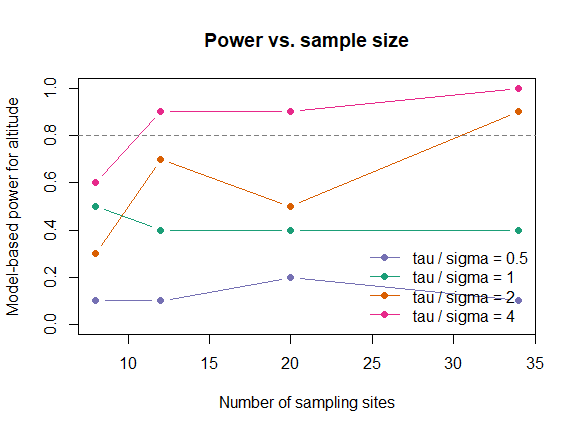

*Power responds to sampling sites and the tau / sigma signal ratio.* Each point is the proportion of 10 simulated data sets in which the altitude coefficient had the correct sign and a two-sided Wald p-value below alpha = 0.05. Effective Wishart degrees of freedom are held fixed at nu = 100. The small demonstration grid leaves visible Monte Carlo variation.

```r
plot(NA, xlim = range(site_power$sample_size), ylim = c(0, 1),
     xlab = "Number of sampling sites", ylab = "Model-based power for altitude",
     main = "Power vs. sample size")
for (signal_ratio in signal_ratios) {
  sub <- site_power[site_power$signal_ratio == signal_ratio, ]
  lines(sub$sample_size, sub$power, type = "b", pch = 19,
        col = cols[as.character(signal_ratio)])
}
abline(h = 0.8, lty = 2, col = "grey50")
legend("bottomright", legend = paste("tau / sigma =", signal_ratios),
       col = cols, lty = 1, pch = 19, bty = "n")
```

Across repeated assessments, more sites generally improve power because the fitted covariance structure is informed by a larger sample from the landscape. The ten-replicate teaching grid is intentionally small, so its curves are not perfectly monotone. Site placement also matters. Real assessments should use more replicates and compare plausible placement strategies rather than treat sample count as the only design decision.

## 7 Comparing sampling strategies and candidate models

`covariance_response_power()` automates the same loop across **sampling designs**: it subsets the focal sites in the surface to a target sample size, optionally using different placement strategies, simulates responses, refits candidate models, and summarizes recovery. Because all designs reuse one graph, it is fast.

Here we compare three sample sizes under two placement strategies, and we fit two candidate models per replicate: the true two-covariate model and a reduced altitude-only model. This lets us measure both **parameter recovery** and **model-selection** performance.

```r
power <- covariance_response_power(
  theta             = theta_true,
  formula           = ~ forestcover + altitude,
  data              = surface,
  sample_sizes      = c(10, 20, 34),
  strategies        = c("spacefill", "random"),
  conductance_model = loglinear_conductance,
  fit_models = list(
    full          = list(formula = ~ forestcover + altitude),
    altitude_only = list(formula = ~ altitude)
  ),
  tau        = tau_true,
  sigma      = sigma_true,
  nu         = 100,
  nsim       = 20,    # increase for smoother estimates in a real study
  n_designs  = 2,     # random designs evaluated per sample size
  seed       = 1,
  control    = NewtonRaphsonControl(maxit = 10, verbose = FALSE)
)

power
```

```
#> Covariance-response power assessment
#> Simulations per design: 20
#> Sample sizes: 10, 20, 34
#> Strategies: spacefill, random
#>
#>   strategy sample_size         model n_replicates fit_rate conductance_power
#>     random          10 altitude_only           40        1             0.000
#>     random          10          full           40        1             0.725
#>  spacefill          10 altitude_only           20        1             0.000
#>  spacefill          10          full           20        1             0.850
#>     random          20 altitude_only           40        1             0.000
#>     random          20          full           40        1             0.925
#>  spacefill          20 altitude_only           20        1             0.000
#>  spacefill          20          full           20        1             0.950
#>     random          34 altitude_only           40        1             0.000
#>     random          34          full           40        1             0.950
#>  spacefill          34 altitude_only           20        1             0.000
#>  spacefill          34          full           20        1             0.950
#>  mean_conductance_cor mean_conductance_spearman selected_AIC_rate
#>             0.4246024                 0.7130792             0.525
#>             0.8609271                 0.9222822             0.475
#>             0.4445664                 0.7506097             0.150
#>             0.9135440                 0.9636633             0.850
#>             0.4462733                 0.7506097             0.100
#>             0.9611628                 0.9718408             0.900
#>             0.4455321                 0.7506097             0.050
#>             0.9721211                 0.9888001             0.950
#>             0.4471640                 0.7506097             0.000
#>             0.9823494                 0.9854258             1.000
#>             0.4466639                 0.7506097             0.000
#>             0.9856608                 0.9890036             1.000
#>  selected_AICc_rate mean_elapsed conductance_cor_threshold all_parameter_power
#>               0.925      1.34500                       0.9               0.800
#>               0.075      2.12525                       0.9               0.250
#>               0.650      1.80450                       0.9               0.900
#>               0.350      4.10250                       0.9               0.100
#>               0.225      1.37675                       0.9               0.950
#>               0.775      2.26950                       0.9               0.500
#>               0.050      1.54900                       0.9               1.000
#>               0.950      2.83600                       0.9               0.700
#>               0.075      1.60675                       0.9               1.000
#>               0.925      2.87550                       0.9               0.875
#>               0.050      1.60450                       0.9               1.000
#>               0.950      3.04000                       0.9               0.950
```

### 7.1 Scenario-level summary

The `summary` table has one row per (strategy, sample size, model):

```r
power$summary[, c("strategy", "sample_size", "model",
                  "fit_rate", "conductance_power",
                  "mean_conductance_cor", "selected_AIC_rate")]
```

```
#>     strategy sample_size         model fit_rate conductance_power
#> 1     random          10 altitude_only        1             0.000
#> 7     random          10          full        1             0.725
#> 2  spacefill          10 altitude_only        1             0.000
#> 8  spacefill          10          full        1             0.850
#> 3     random          20 altitude_only        1             0.000
#> 9     random          20          full        1             0.925
#> 4  spacefill          20 altitude_only        1             0.000
#> 10 spacefill          20          full        1             0.950
#> 5     random          34 altitude_only        1             0.000
#> 11    random          34          full        1             0.950
#> 6  spacefill          34 altitude_only        1             0.000
#> 12 spacefill          34          full        1             0.950
#>    mean_conductance_cor selected_AIC_rate
#> 1             0.4246024             0.525
#> 7             0.8609271             0.475
#> 2             0.4445664             0.150
#> 8             0.9135440             0.850
#> 3             0.4462733             0.100
#> 9             0.9611628             0.900
#> 4             0.4455321             0.050
#> 10            0.9721211             0.950
#> 5             0.4471640             0.000
#> 11            0.9823494             1.000
#> 6             0.4466639             0.000
#> 12            0.9856608             1.000
```

Key columns:

- **`fit_rate`**: fraction of replicates that converged. Values below 1 flag a design where the model is hard to fit (often too few sites).
- **`conductance_power`**: fraction of replicates whose fitted conductance surface has a Pearson correlation with the generating surface above `conductance_cor_threshold` (default 0.9). This measures recovery of the relative spatial pattern, not its absolute scale or an ecological mechanism. It is useful for spline models whose basis coefficients are not individually interpretable.
- **`mean_conductance_cor`**: average correlation between the fitted and true conductance surfaces.
- **`selected_AIC_rate`**: how often each model had the lowest AIC within the specified, comparable candidate set. For the `full` model, this is the rate at which the generating formula ranked first among those candidates.

### 7.2 Parameter-level summary

`parameter_summary` reports per-coefficient power, bias, RMSE, and confidence interval coverage:

```r
power$parameter_summary[
  power$parameter_summary$model == "full",
  c("strategy", "sample_size", "parameter",
    "power", "bias", "rmse", "coverage")
]
```

```
#>     strategy sample_size   parameter power          bias       rmse coverage
#> 7     random          10    altitude 0.725 -0.2400864368 0.98008516    0.925
#> 13    random          10 forestcover 0.250  0.2158918115 0.88777843    0.900
#> 8  spacefill          10    altitude 0.650  0.0025741755 0.12773899    0.950
#> 14 spacefill          10 forestcover 0.250  1.2020567569 4.94001784    0.950
#> 9     random          20    altitude 0.750  0.0002667343 0.15147266    0.950
#> 15    random          20 forestcover 0.675  0.0295385668 0.25543407    1.000
#> 10 spacefill          20    altitude 0.900 -0.0081386272 0.14531956    0.900
#> 16 spacefill          20 forestcover 0.800  0.1059249666 0.31930860    0.950
#> 11    random          34    altitude 0.975 -0.0087829656 0.10477135    0.975
#> 17    random          34 forestcover 0.900  0.0161193549 0.16872282    1.000
#> 12 spacefill          34    altitude 1.000 -0.0216626697 0.09216619    0.950
#> 18 spacefill          34 forestcover 0.950  0.0166800620 0.14816763    0.950
```

What to look for:

- **`power`**: proportion of all simulated replicates in which the coefficient had the generating sign and a two-sided Wald p-value below `alpha`. Failed or boundary fits count as non-detections. Choose a target such as 0.8 before the assessment rather than treating it as a universal threshold.
- **`bias`**: average estimate minus the generating value. Persistent bias can reflect model misspecification, boundary behavior, optimization failures, or a design too small for the asymptotic approximation.
- **`rmse`**: typical estimation error; should shrink as sample size grows.
- **`coverage`**: fraction of 95% confidence intervals that contain the truth. Well-calibrated intervals give ~0.95. Coverage well below 0.95 means the reported uncertainty is too optimistic for that design.

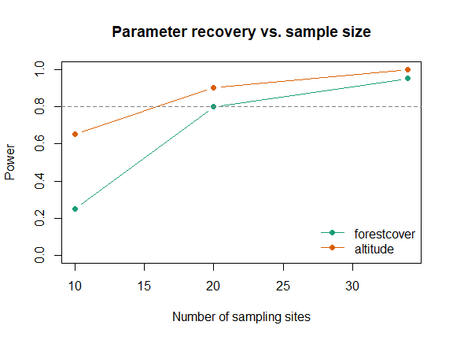

*Power to recover each conductance coefficient as a function of sample size (spacefill design, generating formula).* The dashed line marks 80% power.

```r
ps <- power$parameter_summary
ps <- ps[ps$model == "full" & ps$strategy == "spacefill", ]

cols <- c(forestcover = "#1b9e77", altitude = "#d95f02")
plot(NA, xlim = range(ps$sample_size), ylim = c(0, 1),
     xlab = "Number of sampling sites", ylab = "Power",
     main = "Parameter recovery vs. sample size")
for (p in names(cols)) {
  sub <- ps[ps$parameter == p, ]
  sub <- sub[order(sub$sample_size), ]
  lines(sub$sample_size, sub$power, type = "b", pch = 19, col = cols[p])
}
abline(h = 0.8, lty = 2, col = "grey50")
legend("bottomright", legend = names(cols), col = cols,
       lty = 1, pch = 19, bty = "n")
```

## 8 Interpreting and acting on the results

| Question | Column(s) to read | Decision rule |
| --- | --- | --- |
| Enough sites? | `parameter_summary$power`, `conductance_power` | Pick the smallest sample size that reaches your predeclared recovery target under conservative scenarios. |
| Enough marker information? | power-vs-`nu` curves | Identify the smallest plausible effective `nu` past the power elbow under conservative scenarios. |
| Which site placement? | compare `strategy` rows | Prefer the strategy with higher power / surface correlation at equal cost. |
| Trustworthy intervals? | `parameter_summary$coverage` | Require coverage near 0.95 before trusting reported CIs. |

A few practical notes:

- **Increase `nsim`.** This vignette uses small `nsim` so it builds relatively quickly. For a real assessment use at least 100-500 simulations per design so that power and coverage estimates are stable.
- **Match the simulation to your expectations.** The answer depends on `theta`, `tau`, and `sigma`. If you are unsure, run the assessment across a grid of plausible effect sizes and $\tau / \sigma$ ratios, then report the range.
- **Use and report defensible `nu` values.** Markers in linkage disequilibrium are not independent, so the effective `nu` can be smaller than the raw marker count. Planning with an optimistic `nu` overstates precision and power. Use locus count as the primary microsatellite value and report a sensitivity analysis.
- **Spline and Gaussian models.** For non-linear conductance models the individual coefficients are not interpretable; lean on `conductance_power` and `mean_conductance_cor` rather than per-parameter power. Pass the relevant factory via `conductance_model` and `fit_models`.

## 9 Quick reference

```r
library(terradish)
library(terra)

# 1. Build a landscape template (saveStack = TRUE enables site subsetting)
surface <- conductance_surface(covariates, coords,
                               directions = 8, saveStack = TRUE)

# 2. One simulated covariance matrix from specified generating parameters
sim <- simulate_covariance_response(
  theta = c(x1 = 0.6, x2 = -0.4), formula = ~ x1 + x2,
  data = surface, tau = 2, sigma = 1, nu = 100, seed = 1
)

# 3. Refit to check recovery
fit <- terradish(sim$covariance ~ x1 + x2, data = surface,
                 conductance_model = loglinear_conductance,
                 measurement_model = wishart_covariance, nu = 100)
coef(fit)

# 4. Full design assessment across sample sizes / strategies / models
power <- covariance_response_power(
  theta = c(x1 = 0.6, x2 = -0.4), formula = ~ x1 + x2,
  data = surface, sample_sizes = c(10, 20, 30),
  strategies = c("spacefill", "random"),
  tau = 2, sigma = 1, nu = 100, nsim = 200, seed = 1
)
power$summary            # fit rate, conductance recovery, model selection
power$parameter_summary  # power, bias, RMSE, coverage per coefficient
```

## 10 Summary of key functions

| Function | Purpose |
| --- | --- |
| `conductance_surface()` | Build the landscape template; `saveStack = TRUE` enables site subsetting |
| `simulate_covariance_response()` | One covariance matrix simulated from known parameters |
| `terradish()` | Refit a simulated data set to check parameter recovery |
| `covariance_response_power()` | Full design sweep across sample sizes, strategies, and models |
| `$summary` | Per-scenario fit rate, conductance recovery, and model-selection rate |
| `$parameter_summary` | Per-coefficient power, bias, RMSE, and interval coverage |

## 11 See also

- `vignette("wishart-covariance", package = "terradish")`: the covariance workflow and a full explanation of `nu`.
- `vignette("getting-started", package = "terradish")`: the core modeling workflow.
- `vignette("model-comparison", package = "terradish")`: AIC, likelihood ratio tests, and cross-validation for real data.